# LFMM_vignette

## Comparing different LFMM methods with `lfmm_run()`

The main function in algatr that runs LFMM is `lfmm_run()`. This function requires that users provide the dosage matrix (`gen`), the extracted environmental variables (`env`), the number of latent factors (`K`), and the LFMM method (`lfmm_method`).

Importantly, LFMM can be performed using two main methods (`"lasso"` or `"ridge"`), which primarily differ in the penalized loss functions that are incorporated into the least-squares minimization and are specified using the `lfmm_method` argument. The least-squares minimization is how statistical significance is determined for SNPs being associated with environmental variables. The primary difference between the two methods is that the ridge method minimizes the problem with an L^2 penalty, whereas the lasso method minimizes with an L^1 penalty. According to [Caye & François 2017](https://bcm-uga.github.io/lfmm/articles/lfmm#starting-with-lfmm), a user would want to select the lasso method (i.e., L^1-norm) to induce “sparsity on the fixed effects, and corresponds to the prior information that not all response variables may be associated with the variables of interest. More specifically, the prior implies that a limited number of rows of the effect size matrix B are effectively non-zero.” The ridge penalty is further described in [Caye et al. 2019](https://academic.oup.com/mbe/article/36/4/852/5290100).

One other argument to be aware of within `lfmm_run()` is the adjustment of p-values, specified using `p_adj`. There are two options for `p_adj`: `"fdr"`, which adjusts calibrated p-values based on the false discovery rate (the default). Other options for p-value adjustment can be found within the `p.adjust()` function in the stats package.

Finally, the last argument to be aware of within `lfmm_run()` is `calibrate`, which calibrates p-values based on resulting z-scores. There are two options for this argument: `"gif"` (the default), and `"median+MAD"`. From the LFMM documentation: “If the”gif” option is set (default), significance values are calibrated by using the genomic control method. Genomic control uses a robust estimate of the variance of z-scores called “genomic inflation factor”. If the “median+MAD” option is set, the pvalues are calibrated by computing the median and MAD of the zscores. If NULL, the pvalues are not calibrated.”

Now that we’ve identified the number of latent factors to provide in our model, let’s run LFMM using both ridge and lasso penalties with default settings (i.e., FDR p-value adjustment and the “gif” calibration).

```r
ridge_results <- lfmm_run(gen, env, K = 6, lfmm_method = "ridge")
lasso_results <- lfmm_run(gen, env, K = 6, lfmm_method = "lasso")
```

The results object from `lfmm_run()` contains 5 elements:

- `lfmm_snps`: a list of candidate SNPs that are statistically significantly associated with environmental variables, including all relevant information pertaining to the LFMM analysis (e.g., p-values, fixed effects, etc.)
- `df`: all of the SNPs and their associations, including all relevant information pertaining to the LFMM analysis
- `model`: parameters of the LFMM model, including matrices *B*, *U*, and *V*
- `lfmm_test_result`: results from association testing
- `K`: the number of latent factors that LFMM was run using (in our case, 6)

## Visualizing LFMM results

There are three main ways we can visualize the results from our LFMM analysis. Each of these is automatically produced by `lfmm_run()`, but you can produce them individually as well with the functions below.

- `lfmm_table()`: Build a table with each SNP and its association (and p-value) with each environmental variable. This function allows for quite a bit of customization in terms of what is displayed:
  - `sig`: the significance threshold (alpha value)
  - `sig_only`: whether to only display SNPs above the significance threshold
  - `top`: if there are SNPs that are significantly associated with multiple environmental variables, only display the top association (i.e., variable with the maximum B value)
  - `order`: whether to order the SNPs in descending order based on their B value, otherwise they will be ordered based on environmental variable
  - `var`: only display SNPs associated with one environmental variable
  - `nrow`: the number of rows to display
  - `digits`: the number of decimal places to include
  - `footnotes`: whether to include footnotes describing the variables displayed
  - `p_adj`: whether p-values were adjusted in `lfmm_run()`
- `lfmm_qqplot()`: Build a QQ-plot (quantile-quantile plot) which plots expected quantiles (percentiles) against p-values.
- `lfmm_manhattanplot()`: Build a Manhattan plot with defined significance threshold.

### Building a table of SNP associations with `lfmm_table()`

Let’s see what the top candidate SNPs were for each of our LFMM runs:

```r
# Build tables for each of our LFMM runs, displaying only significant SNPs and ordering according to effect size (B)
lfmm_table(lasso_results$df, order = TRUE)
```

| snp | variable | B<sup>1</sup> | z-score | p-value | calibrated z-score | calibrated p-value | adjusted p-value |
| --- | --- | --- | --- | --- | --- | --- | --- |
| Locus_2338 | CA_rPCA3 | -0.26 | -4.44 | 0 | 19.19 | 0 | 0.01 |
| Locus_125 | CA_rPCA3 | 0.18 | 3.80 | 0 | 14.09 | 0 | 0.04 |
| Locus_859 | CA_rPCA3 | 0.18 | 3.80 | 0 | 14.09 | 0 | 0.04 |
| Locus_249 | CA_rPCA2 | 0.14 | 4.95 | 0 | 16.78 | 0 | 0.04 |
| Locus_1051 | CA_rPCA3 | 0.09 | 3.80 | 0 | 14.09 | 0 | 0.04 |
| Locus_562 | CA_rPCA2 | -0.05 | -4.74 | 0 | 15.42 | 0 | 0.04 |

<sup>1</sup> LFMM effect size

```r
lfmm_table(ridge_results$df, order = TRUE)
```

| snp | variable | B<sup>1</sup> | z-score | p-value | calibrated z-score | calibrated p-value | adjusted p-value |
| --- | --- | --- | --- | --- | --- | --- | --- |
| Locus_2338 | CA_rPCA3 | -0.29 | -5.25 | 0 | 25.50 | 0 | 0.00 |
| Locus_125 | CA_rPCA3 | 0.17 | 4.08 | 0 | 15.43 | 0 | 0.02 |
| Locus_859 | CA_rPCA3 | 0.17 | 4.08 | 0 | 15.43 | 0 | 0.02 |
| Locus_2947 | CA_rPCA2 | -0.13 | -7.49 | 0 | 38.03 | 0 | 0.00 |
| Locus_512 | CA_rPCA3 | 0.13 | 3.85 | 0 | 13.71 | 0 | 0.03 |
| Locus_2014 | CA_rPCA3 | 0.13 | 3.85 | 0 | 13.71 | 0 | 0.03 |
| Locus_1524 | CA_rPCA2 | -0.12 | -4.84 | 0 | 15.89 | 0 | 0.00 |
| Locus_249 | CA_rPCA2 | 0.12 | 5.92 | 0 | 23.78 | 0 | 0.00 |
| Locus_2338 | CA_rPCA2 | -0.11 | -4.00 | 0 | 10.84 | 0 | 0.03 |
| Locus_2133 | CA_rPCA2 | -0.10 | -6.45 | 0 | 28.25 | 0 | 0.00 |
| Locus_831 | CA_rPCA2 | -0.10 | -5.07 | 0 | 17.46 | 0 | 0.00 |
| Locus_2669 | CA_rPCA2 | -0.09 | -5.29 | 0 | 18.98 | 0 | 0.00 |
| Locus_2703 | CA_rPCA2 | 0.09 | 4.02 | 0 | 10.97 | 0 | 0.03 |
| Locus_1278 | CA_rPCA2 | -0.09 | -5.48 | 0 | 20.33 | 0 | 0.00 |
| Locus_786 | CA_rPCA2 | -0.09 | -4.31 | 0 | 12.61 | 0 | 0.01 |
| Locus_1318 | CA_rPCA2 | -0.09 | -6.51 | 0 | 28.74 | 0 | 0.00 |
| Locus_1051 | CA_rPCA3 | 0.09 | 4.08 | 0 | 15.43 | 0 | 0.02 |
| Locus_2045 | CA_rPCA2 | -0.08 | -5.72 | 0 | 22.21 | 0 | 0.00 |
| Locus_1319 | CA_rPCA2 | -0.08 | -5.59 | 0 | 21.15 | 0 | 0.00 |
| Locus_1745 | CA_rPCA2 | -0.08 | -5.59 | 0 | 21.15 | 0 | 0.00 |
| Locus_2670 | CA_rPCA2 | -0.08 | -6.91 | 0 | 32.38 | 0 | 0.00 |
| Locus_138 | CA_rPCA2 | 0.08 | 4.66 | 0 | 14.73 | 0 | 0.01 |
| Locus_903 | CA_rPCA2 | -0.07 | -5.06 | 0 | 17.39 | 0 | 0.00 |
| Locus_870 | CA_rPCA2 | -0.06 | -5.75 | 0 | 22.40 | 0 | 0.00 |
| Locus_2426 | CA_rPCA2 | -0.06 | -5.75 | 0 | 22.40 | 0 | 0.00 |
| Locus_2699 | CA_rPCA2 | -0.06 | -5.75 | 0 | 22.40 | 0 | 0.00 |
| Locus_2145 | CA_rPCA2 | -0.06 | -3.95 | 0 | 10.55 | 0 | 0.04 |
| Locus_2770 | CA_rPCA2 | -0.06 | -4.11 | 0 | 11.47 | 0 | 0.02 |
| Locus_562 | CA_rPCA2 | -0.06 | -7.05 | 0 | 33.70 | 0 | 0.00 |
| Locus_1414 | CA_rPCA2 | 0.06 | 3.90 | 0 | 10.30 | 0 | 0.04 |
| Locus_974 | CA_rPCA2 | -0.04 | -5.59 | 0 | 21.15 | 0 | 0.00 |
| Locus_1254 | CA_rPCA2 | -0.04 | -5.59 | 0 | 21.15 | 0 | 0.00 |
| Locus_3116 | CA_rPCA2 | -0.04 | -5.59 | 0 | 21.15 | 0 | 0.00 |
| Locus_2421 | CA_rPCA2 | -0.04 | -4.38 | 0 | 13.04 | 0 | 0.01 |
| Locus_637 | CA_rPCA2 | 0.04 | 4.22 | 0 | 12.06 | 0 | 0.02 |

<sup>1</sup> LFMM effect size

As you can see from the above, the penalty chosen makes quite a bit of difference in terms of how many significant SNPs are found (only 6 with the lasso method, but 35 with the ridge method). However, the three SNPs with the largest effect size are the same between the two methods (loci 2338, 125, and 859), and the effect sizes and p-values are comparable. The tables also contain columns for calibrated z-score, calibrated p-values, and adjusted p-values. Recall that adjusted p-values are calculated based on setting the `p_adj` argument; in our case, these are adjusted based on the false discovery rate, which is why they differ from non-adjusted p-values (i.e., values in the p-value column).

Let’s only look at SNPs significantly associated with the PCA2 environmental variable from the lasso method:

```r
lfmm_table(lasso_results$df, order = TRUE, var = "CA_rPCA2")
```

| snp | variable | B<sup>1</sup> | z-score | p-value | calibrated z-score | calibrated p-value | adjusted p-value |
| --- | --- | --- | --- | --- | --- | --- | --- |
| Locus_249 | CA_rPCA2 | 0.14 | 4.95 | 0 | 16.78 | 0 | 0.04 |
| Locus_562 | CA_rPCA2 | -0.05 | -4.74 | 0 | 15.42 | 0 | 0.04 |

<sup>1</sup> LFMM effect size

```r
# Be aware that if significant SNPs < nrow, function will return NULL object
# lfmm_table(lasso_results$df, sig_only = FALSE, order = FALSE, nrow=10)

# Similarly, the same will occur if you try to specify a variable that is not significantly associated with a SNP
# lfmm_table(lasso_results$df, sig_only = TRUE, var = "CA_rPCA1")
```

### Building a QQplot with `lfmm_qqplot()`

A QQplot plots theoretical quantiles against p-value quantiles, providing a way to visualize the normality of the test significance values. The line that is plotted runs through the intercept and has a slope of 1. The points should ideally fall along this reference line:

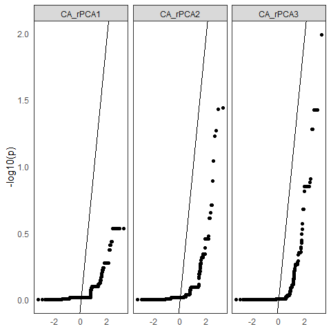

```r
lfmm_qqplot(lasso_results$df)
```

### Building a Manhattan plot using `lfmm_manhattanplot()`

Manhattan plots are helpful ways to visualize the position of the outlier SNPs across the genome, as well as how much they exceed a user-specified significance threshold for each environmental variable.

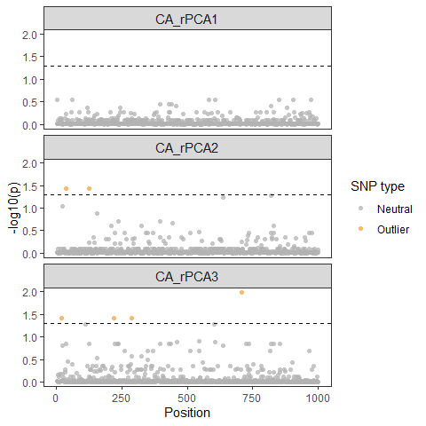

```r
# As displayed in our table from above, only six SNPs are visible on the lasso method plots as outliers:
lfmm_manhattanplot(lasso_results$df, sig = 0.05)
```

For the ridge method LFMM run, we can see that there are (a) more outliers than the lasso method above, and (b) the majority of these outliers are associated with environmental PC2.

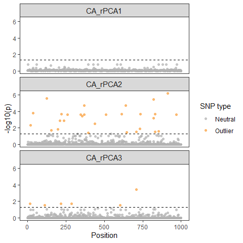

```r
lfmm_manhattanplot(ridge_results$df, sig = 0.05)
```

## Running LFMM with `lfmm_do_everything()`

The algatr package also has an option to run all of the above functionality in a single function, `lfmm_do_everything()`. This function will automatically extract relevant values from our environmental layers given our coordinate data; it will also automatically convert a vcf object to a dosage matrix for us. The output looks the same as the output from `lfmm_run()` above, and plots will be automatically produced. **Please be aware that the `do_everything()` functions are meant to be exploratory. We do not recommend their use for final analyses unless certain they are properly parameterized.**

```r
results <- lfmm_do_everything(gen = gen, env = CA_env, coords = liz_coords, lfmm_method = "lasso", K_selection = "tracy_widom")
```

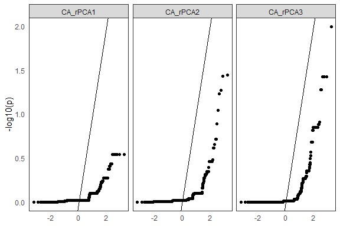

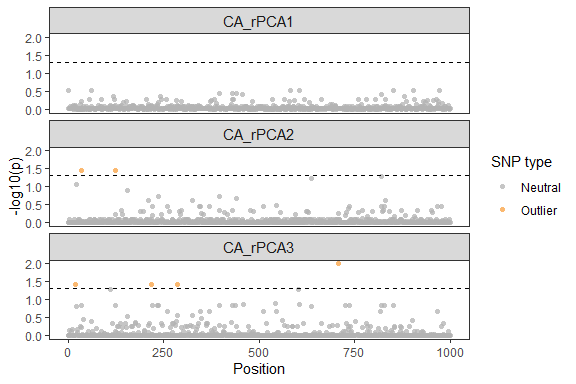

## Additional documentation and citations

|  | Citation/URL | Details |
| --- | --- | --- |
| Main manuscript describing method | [Caye et al. 2019](https://academic.oup.com/mbe/article/36/4/852/5290100); see [here](https://bcm-uga.github.io/lfmm/index.html) for documentation | Paper and code describing LFMM2 |
| Associated literature | [Frichot et al. 2013](https://academic.oup.com/mbe/article/30/7/1687/972098) | Paper describing LFMM |
| Associated code | [Wang et al. 2020](https://cran.r-project.org/web/packages/AssocTests/index.html) | algatr performs a Tracy-Widom test using the `tw()` function in the AssocTests package |
| Associated code | [Blog post on automatic K selection](https://chazhyseni.github.io/NALgen/post/determining_bestk/) | algatr’s automatic K selection code |
| Additional code | [Frichot & Francois 2015](https://rdrr.io/bioc/LEA/) | The LEA package provides wrapper functions for LFMM (using the `lfmm2()` function |

Retrieve LFMM’s vignette:

```r
vignette("lfmm")
```